# Brownlows Bets

Nicole Orizino

Spring 2021

# 1 Introduction

At the first day of class there are 35 students in Math Statistics class and professor Brownlow always proposes this bet to his students "I will wager $2 to your bet of $1 that at least two people in today’s class have the same birthday. He tells me he has made that bet 637 times so far. Where do you think his profits are? Discuss this in a markdown document

Report git commit structure: There are 3 questions and there should be at least 3 separate commits, at least one dealing with each of the 3 questions. 1. What are the fair odds for a bet on matching birthdays in a 35 person class. 2. For what size class is a 2:1 odds bet fair. 3. How much money would Brownlow be expected to end up with if the bets went as described.

# 2 What are the fair odds

```r
URN = 1:365
```

# 3 WHat is Brownlow’s average profet/loss

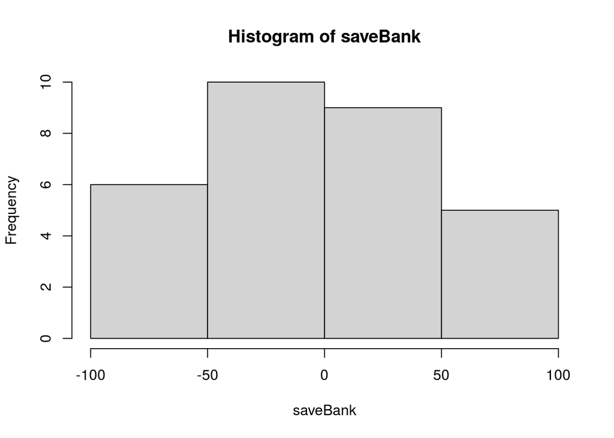

```r
classSize=35
WinAmount=1
LoseAmount=4.25
bank = 0
saveBank=vector('numeric')
test = vector('numeric')
for(j in 1:30){
  bank = 0
for(i in 1:637){
test = sample(URN, classSize, replace = TRUE)
ifelse(length(unique(test))==classSize,
       (bank=bank-LoseAmount),(bank=bank+WinAmount))
saveBank [j] = bank
}
}
hist(saveBank)
```

Dr. J should pay $4.25 in lose to keep it fair.

```r
favstats(saveBank)
```

```
##  min      Q1 median   Q3   max mean       sd  n missing
##  -98 -32.375   -3.5 38.5 96.25 0.35 52.22653 30       0
```